# Assignment 1

## Getting data

We have downloaded the zip file into our desktop and we are going to unzip it and read the document it has using R.

```r
c=unzip('C:\\Users\\weey\\Desktop\\Coursera\\repdata%2Fdata%2Factivity.zip')
b=read.csv(c)
library(dplyr)
```

```r
library(ggplot2)
```

## Splitting the steps by dates and plotting the Histogram

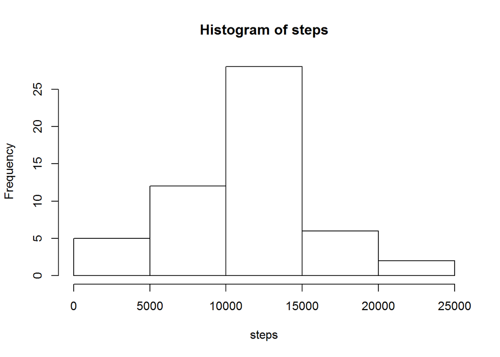

```r
g=split(b$steps,b$date)
steps=sapply(g,sum)
hist(steps)
```

## Getting the mean

With the data that we have now,we will calculate the mean number of steps taken each day

```r
mean(steps,na.rm=TRUE)
```

```
## [1] 10766.19
```

## Getting the median

With the data that we have now,we will find the median of the total number of steps taken each day

```r
median(steps,na.rm=TRUE)
```

```
## [1] 10765
```

## Time series plot

Make a time series plot of the 5-minute interval (x-axis) and the average number of steps taken, averaged across all days

We will first group the number of steps in the different interval and plot the time series thereafter.

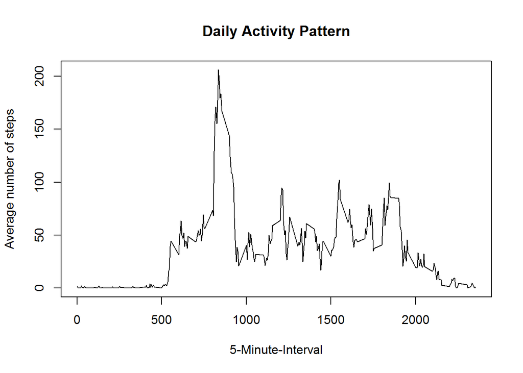

```r
q = tapply(b$steps,b$interval,mean,na.rm= TRUE,simplify = TRUE)
plot(y = q, x = names(q), type = "l", xlab = "5-Minute-Interval",
         main = "Daily Activity Pattern", ylab = "Average number of steps")
```

This is the time interval that contains the maximum no. of steps

```r
sort(q,decreasing = TRUE)[1]
```

```
##      835
## 206.1698
```

## Inputting missing values

This is the no. of rows with NA in the dataset

```r
w=complete.cases(b)
r=b[!w,]
nrow(r)
```

```
## [1] 2304
```

We will now fill the N.A with the mean for that 5-min interval

```r
f=b
for( i in 1:nrow(f)) {
  if (is.na(f$steps[i])){
              e=f$interval[i]
              t=q[as.character(e)]
       f$steps[i]=t[[1]]
  }


}
```

This is the new histogram

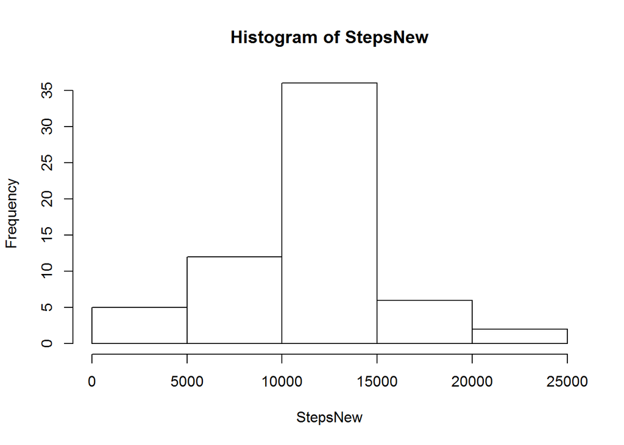

```r
h=split(f$steps,f$date)
StepsNew=sapply(h,sum)
hist(StepsNew)
```

This is the new mean

```r
mean(StepsNew,na.rm=TRUE)
```

```
## [1] 10766.19
```

This is the new median

```r
median(StepsNew,na.rm=TRUE)
```

```
## [1] 10766.19
```

The values are the same as the initiate mean value.

## Activity pattern between weekdays and weekends

We gona indicate whether a given date is a weekday or weekend day.

```r
weekDay=as.Date(f$date)
weekDay=weekdays(weekDay)

newdata=cbind(f,weekDay)
levels(newdata$weekDay)<-list(weekday= c("Monday","Tuesday","Wednesday","Thursday","Friday"), weekend=c("Saturday","Sunday"))
```

We will now plot out the result

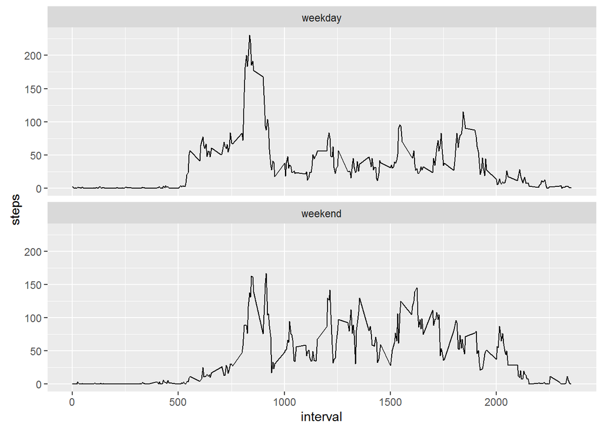

```r
v=newdata %>% group_by(interval,weekDay) %>% summarise(steps=mean(steps))
ggplot(v,aes(x=interval,y=steps),colour=weekDay) +geom_line()+facet_wrap(~weekDay, ncol = 1, nrow=2)
```